# Data Modeling

2025-05-04

```r
library(lubridate)
library(tidyverse)
library(caret)
library(dplyr)
library(ggthemes)
library(glmnet)
library(MASS)
library(class)
library(pROC)
library(randomForest)
library(ggplot2)
library(corrplot)
library(GGally)
library(rpart)
library(rpart.plot)
library(xgboost)
library(gbm)
library(doParallel)
library(survival)
library(survminer)
boa_data <- read.csv("data/cleaned_data/cleaned_data.csv")
boa_data$closed <- as.factor(boa_data$closed)
```

```r
# Recode region: 1 - rural, 2 - micropolitan, 3 - metropolitan
boa_data <- boa_data %>%
  mutate(region_code = case_when(
    is_metropolitan == 1 ~ 3,
    is_micropolitan == 1 ~ 2,
    TRUE ~ 1
  ))
```

## I. Data Exploration

We want to take a look at the data first.

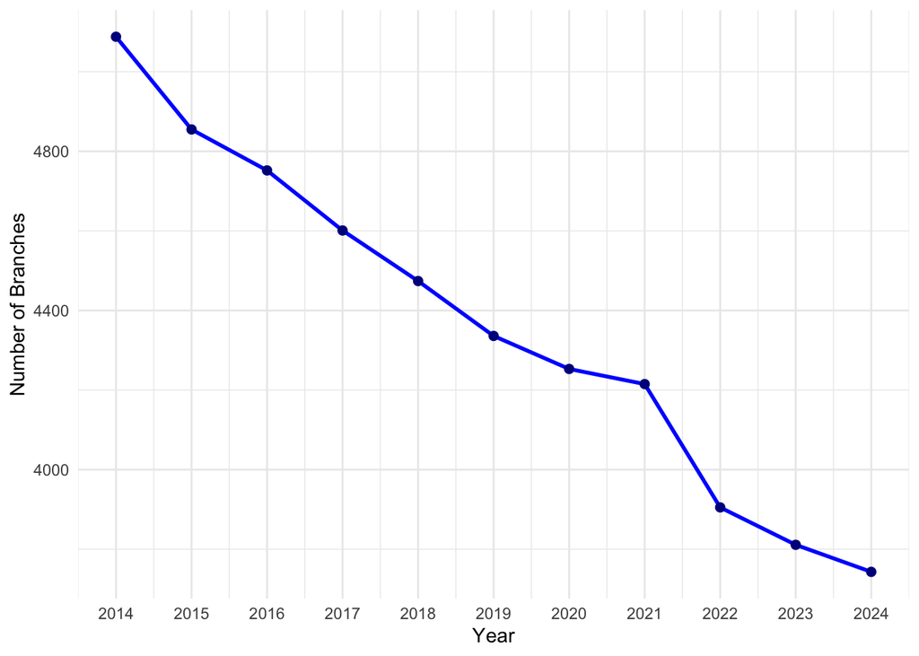

```r
# Number of BoA bank overtime
branches_year <- c(5088, 4855, 4752, 4601,
                  4474, 4336, 4253, 4215,
                  3905, 3811, 3743)
year <- 2014:2024

branch_data <- data.frame(year, branches_year)

ggplot(branch_data, aes(x = year, y = branches_year)) +
  geom_line(color = "blue", size = 1) +
  geom_point(color = "darkblue", size = 2) +
  labs(x = "Year",
       y = "Number of Branches") +
  scale_x_continuous(breaks = 2014:2024) +
  theme_minimal()
```

```r
glimpse(boa_data)
```

```
## Rows: 5,412
## Columns: 35
## $ X                                <int> 0, 1, 2, 3, 4, 5, 6, 7, 8, 9, 10, 11,…
## $ year                             <int> 2024, 2024, 2024, 2024, 2024, 2024, 2…
## $ FDIC_cert                        <int> 3510, 3510, 3510, 3510, 3510, 3510, 3…
## $ bank_name                        <chr> "Bank of America, National Associatio…
## $ adress                           <chr> "100 N Tryon St", "2127 E 17th St", "…
## $ branch_id                        <int> 0, 2, 3, 5, 13, 14, 17, 18, 21, 22, 2…
## $ state_abb                        <chr> "NC", "CA", "CA", "CA", "CA", "CA", "…
## $ branch_service_type              <int> 11, 11, 11, 11, 11, 11, 11, 11, 11, 1…
## $ city                             <chr> "Charlotte", "Santa Ana", "Los Alamit…
## $ county                           <chr> "Mecklenburg", "Orange", "Orange", "V…
## $ combined_stat_area               <int> 172, 348, 348, 348, 488, 488, 348, 34…
## $ combined_stat_area_name          <chr> "Charlotte-Concord, NC-SC", "Los Ange…
## $ deposits                         <int> 318260403, 223324, 371352, 232528, 25…
```

[output cut: 22 more lines]

Now, we want to see within 10 year, how many BoA branches have closed and how many are still opened.

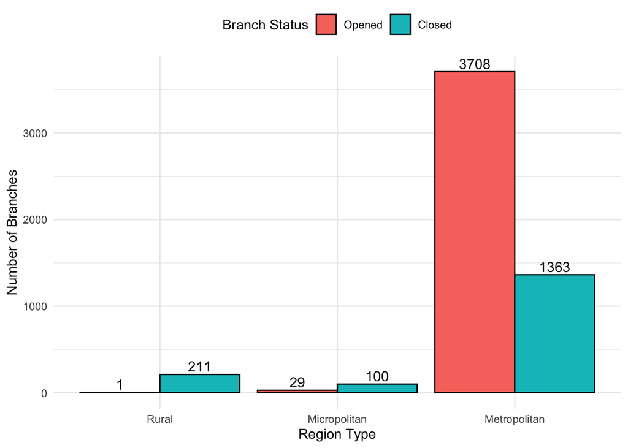

```r
boa_data %>%
  mutate(
    region = recode(factor(region_code),
                    `1` = "Rural",
                    `2` = "Micropolitan",
                    `3` = "Metropolitan"),
    branch_status = recode(factor(closed),
                           `0` = "Opened",
                           `1` = "Closed")
  ) %>%
  group_by(region, branch_status) %>%
  summarise(count = n(), .groups = "drop") %>%
  ggplot(aes(x = region, y = count, fill = branch_status)) +
  geom_bar(stat = "identity", position = position_dodge(width = 0.9), color = "black") +
  geom_text(aes(label = count),
            position = position_dodge(width = 0.9),
            vjust = -0.3, size = 4) +
  labs(
    x = "Region Type",
    y = "Number of Branches",
    fill = "Branch Status"
  ) +
  theme_minimal() +
  theme(
    legend.position = "top",
    plot.title = element_text(size = 14, face = "bold")
  )
```

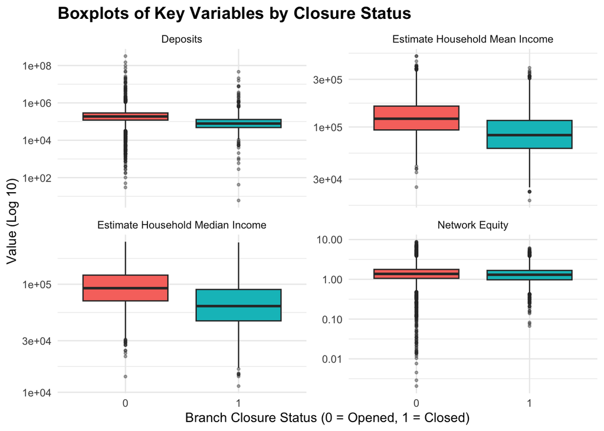

```r
boa_data %>%
  dplyr::select(closed,
         deposits,
         estimate_household_mean_income,
         estimate_household_median_income,
         network_equity) %>%
  pivot_longer(-closed, names_to = "Variable", values_to = "Value") %>%
  mutate(
    Variable = recode(Variable,
      deposits = "Deposits",
      estimate_household_mean_income = "Estimate Household Mean Income",
      estimate_household_median_income = "Estimate Household Median Income",
      network_equity = "Network Equity"
    )
  ) %>%
  ggplot(aes(x = factor(closed), y = Value, fill = factor(closed))) +
  geom_boxplot(outlier.size = 0.8, outlier.alpha = 0.4) +
  facet_wrap(~ Variable, scales = "free_y") +
  scale_y_log10() +
  labs(
    title = "Boxplots of Key Variables by Closure Status",
    x = "Branch Closure Status (0 = Opened, 1 = Closed)",
    y = "Value (Log 10)"
  ) +
  theme_minimal() +
  theme(
    legend.position = "none",
    plot.title = element_text(size = 14, face = "bold")
  )
```

## II. Statistical Analysis

```r
# Clean the deposit change column
boa_data$deposit_change <- as.numeric(boa_data$deposit_change)
boa_data$deposit_change[boa_data$deposit_change %in% c(0, -1, Inf, -Inf)] <- NA
```

```r
df_cleaned <- boa_data %>%
  dplyr::select(closed,
                combined_stat_area,
                deposits,
                branch_share,
                market_share,
                network_equity,
                deposit_change,
                nearby_boa_branches,
                total_nearby_competitor_branches,
                total_nearby_competitor_deposits,
                total_nearby_boa_deposits,
                estimate_household_median_income,
                estimate_household_mean_income,
                region_code) %>%
  filter(if_all(everything(), ~ !is.na(.) & !is.infinite(.)))
```

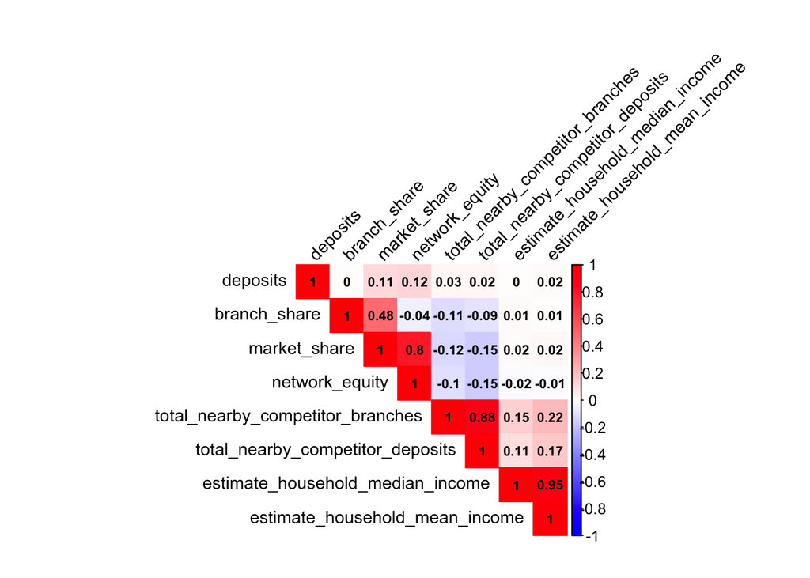

```r
# Select only numeric columns for correlation
numeric_vars <- df_cleaned %>%
  dplyr::select(deposits,
                branch_share,
                market_share,
                network_equity,
                total_nearby_competitor_branches,
                total_nearby_competitor_deposits,
                estimate_household_median_income,
                estimate_household_mean_income)

cor_matrix <- cor(numeric_vars, use = "complete.obs")

corrplot(cor_matrix,
         method = "color",
         type = "upper",
         addCoef.col = "black",
         number.cex = 0.7,
         tl.col = "black",
         tl.srt = 45,
         tl.cex = 0.9,
         col = colorRampPalette(c("blue", "white", "red"))(200),
         mar = c(0, 0, 1, 0)
)
```

### 1. Supervised Learning

We will now split the data into training and testing data (70-30 split).

```r
set.seed(123)
train_index <- createDataPartition(df_cleaned$closed, p = 0.7, list = FALSE)
train_data <- df_cleaned[train_index, ]
test_data <- df_cleaned[-train_index, ]
```

#### 1.1. Decision Tree

We will begin by modeling a simple decision tree model.

```r
# Fit decision tree
tree_model <- rpart(closed ~ .,
                    data = train_data,
                    method = "class",
                    control = rpart.control(minsplit = 10, cp = 0.01))
```

```r
# Predict on test set
pred_class <- predict(tree_model, newdata = test_data, type = "class")

# Confusion matrix and accuracy
conf_mat <- confusionMatrix(pred_class, test_data$closed, positive = "1")
print(conf_mat)
```

```
## Confusion Matrix and Statistics
##
##           Reference
## Prediction    0    1
##          0 1032  127
##          1   60  273
##
##                Accuracy : 0.8747
##                  95% CI : (0.8568, 0.8911)
##     No Information Rate : 0.7319
##     P-Value [Acc > NIR] : < 2.2e-16
##
##                   Kappa : 0.6627
##
##  Mcnemar's Test P-Value : 1.39e-06
##
##             Sensitivity : 0.6825
##             Specificity : 0.9451
##          Pos Pred Value : 0.8198
##          Neg Pred Value : 0.8904
##              Prevalence : 0.2681
##          Detection Rate : 0.1830
##    Detection Prevalence : 0.2232
##       Balanced Accuracy : 0.8138
##
##        'Positive' Class : 1
##
```

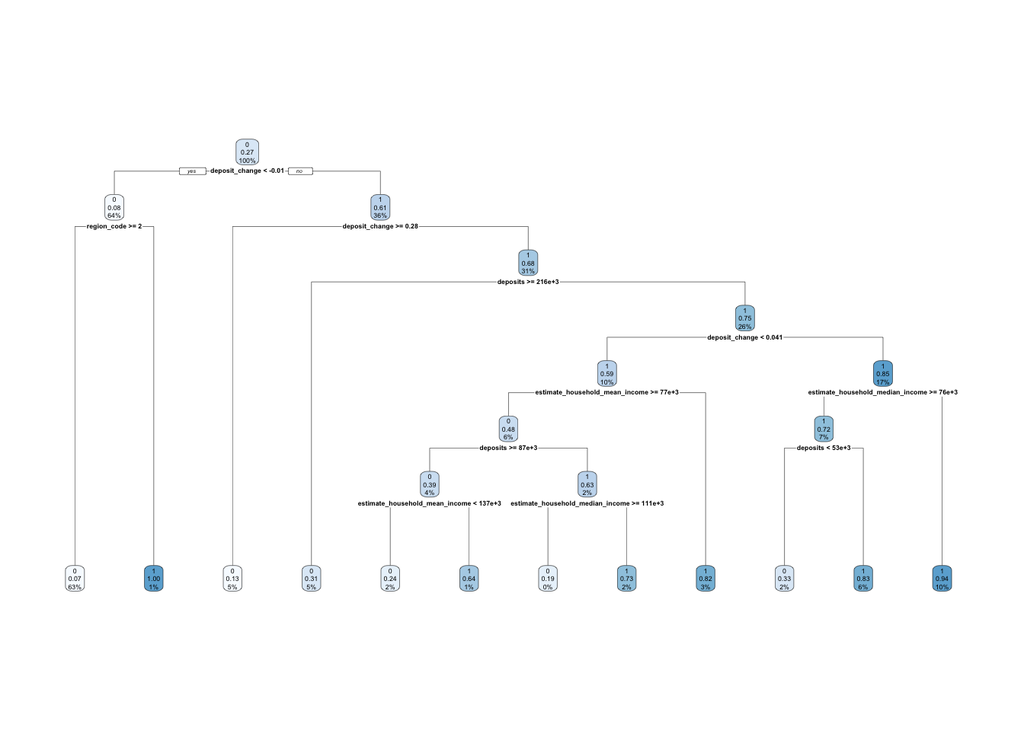

```r
# Plot the tree
rpart.plot(tree_model,
           type = 2,
           extra = 106,
           fallen.leaves = TRUE,
           box.palette = "Blues")
```

We can see that most of the decisions being made in the tree are related to `deposit_change` and `deposit`. This suggests that the tree is biased towards these two features.